# Basics of Experiment Design

### Table of Contents:

- Linear Models
- Degrees of Freedom
- Linear Regression
- Error Quantification

## The System

When doing empiricla modeling or experimental design, the basic principles are the same across differnet kinds of systems. Thus, before talking about empirical modeling, it is important to talk about systems abstractly.

Empirical modeling is an approach that is useful when a detailed physical model of the system is not available or is too expensive. In thise case, we abstract away the details of the system, and reduce it to a black box.

The system has several input variables - the values going into the black box. Input variables are represented with the usual independent variable $x$, and denoted as a vector to indicate there are multiple inputs $\vec{x}$.

Likewise, the system response variables are the values that are measured coming out of the black box. In general these are also vectors, so we denote them with the usual dependent variable $\vec{y}$.

Our efforts in empirical modeling are focused on coming up with a *cheap* and *accurate* mathematical model that can adequately represent our system. To do this, we assume that the system is large and complex, and that the effects of the input variables are integrated. This allows us to talk about increasing or decreasing input variables, and the effect that will have on the system response, without getting into higher order effects (which would imply the system response depends on how fast we increase or decrease the input variables).

```python
from IPython.display import Image
Image(url='http://charlesreid1.com/img/SystemModel.png',width=400)
```

[figure not shown]

## Model Accuracy

To assess how accurate our model is, we have one *and only one* criteria: how closely does the model match reality? In mathematical terms, we are quantifying a residual $\varepsilon$ from our model,

$$ \vec{\varepsilon} = \left| \vec{y} - \vec{\hat{y}} \right| $$

This value represents the deviation of our model from real data. Once we decide on a particular form of a model for $\vec{ \hat{y} }$, we can fit the model to our data by finding model parameters that minimize error.

## Linear Models

The whole idea behind empirical modeling is to come up with simple models to represent the real system, with the sole constraint that we must minimize the residual. We can use any functional form that works (let the data be the guide), but simple models are typically linear.

For a linear model of system responses, each response $y_i$ is a linear function of the input variables $x_i$:

$$ \hat{y}_i = \beta_0 + \sum \beta_i x_i $$

where the $\beta_i$ are the model parameters (polynomial coefficients, in this case). We can also think of each observed system response as consisting of some portion predicted by the model, and a remaining portion not predicted by the model (the residual):

$$ y_i = \hat{y}_i + \varepsilon_i $$

## Degrees of Freedom

Given $n$ input variables and a linear response model, there will be $n+1$ model parameters to fit. This means we need to use $n+1$ observations to fit the $n+1$ parameters, and the remainder of our observations will help us quantify how accurate the model is.

Each observation of the system is an independent piece of information. The total number of independent pieces of information we have about our system is called the "degrees of freedom."

There is a tradeoff, therefore, between making our model more complicated (adding more parameters), which makes it better at matching the data we do have, and getting an accurate assessment of how well our model matches data.

## A Simple Example

Let's look at a simple exmaple to clarify what we're saying. Suppose we have a single input $x$ and a single output $y$. Then a linear model would be the classic linear equation,

$$ y = mx+b $$

which has two parameters, $m$ and $b$.

Now suppose we make 100 observations of our system, and collect 100 pieces of data.

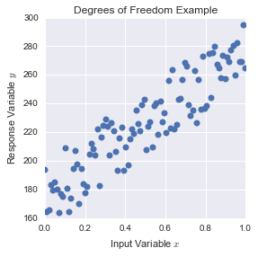

```python
%matplotlib inline
import numpy as np
from numpy.random import rand
from matplotlib.pyplot import *
import seaborn as sns

# Generate input variable values
x = np.linspace(0,1,100)

# Generate system responses
# (Manufactured data)
y = 100.0 * x + 50.0*rand(100,) + 150.0

fig = figure(figsize=(4,4))
ax = fig.add_subplot(111)
ax.plot(x,y,'o')
ax.set_xlabel('Input Variable $x$')
ax.set_ylabel('Response Variable $y$')
ax.set_title('Degrees of Freedom Example')
show()
```

With 100 degrees of freedom and only 2 parameters, we still have 98 degrees of freedom left to quantify how accurate the model is.

We will start by postulating a linear model in its most general form,

$$ \eta = \theta_1 z_1 + \theta_2 z_2 + \dots + \theta_p z_p $$

where $p$ is the number of inputs plus 1 (in this case, $p=2$) and $\eta$ is the model response. Using the notation above, we can write this in terms of model inputs $x_i$, model response $\hat{y}$, and coefficients $\beta$. We also write this with the subscript $e$ to indicate that this relationship holds for a unique set of experimental conditions (recall, we have 100 pieces of data for 100 different experimental conditions):

$$ \hat{y}_e = \beta_{0e} + \beta_{1e} x_{1e} + \beta_{2e} x_{2e} + \dots + \beta_{pe} x_{pe} $$

where $e = 1 \dots 100$.

We can express the real system response $y$ in a like manner, decomposing it into the part captured by the model $\hat{y}$ and the remaining residual term $\varepsilon$:

$$ y = \beta_0 + \beta_1 x_1 + \beta_2 x_2 + \dots + \beta_p x_p + \varepsilon $$

Now, we can write these two equations in matrix form

$$ \mathbf{\hat{Y}} = \mathbf{X} \boldsymbol{\beta} $$

where $\mathbf{X}$ is a matrix containing known input variable values, $\mathbf{\hat{Y}}$ is a vector of model responses, and $\boldsymbol{\beta}$ is the vector of model parameter values (what we're after).

To write an analogous matrix equation for the real system responses, we would write:

$$ \mathbf{Y} = \mathbf{X} \boldsymbol{\beta} + \boldsymbol{\varepsilon} $$

where $\boldsymbol{\varepsilon}$ is the vector of residual values. Because we don't have our model parameters yet, we don't have a model, so can't get $\mathbf{\hat{Y}}$ values to solve the first matrix equation for $\boldsymbol{\beta}$.

Rather, we solve the second matrix equation, by minimizing $\boldsymbol{\varepsilon}$, which is equivalent to minimizing the sum of squares function, given by:

$$ \mathbf{S}(\boldsymbol{\theta}) = (\mathbf{Y} - \mathbf{X}\boldsymbol{\beta})^{\prime} (\mathbf{Y} - \mathbf{X} \boldsymbol{\beta}) $$

This, in turn, can be plugged in and rearranged to obtain the matrix equation that, when solved, yields coefficient values $\boldsymbol{\beta}$ that minimize the sum of squared errors,

$$ \mathbf{X}^{\prime} \mathbf{X} \boldsymbol{\beta} = \mathbf{X}^{\prime} \mathbf{Y} $$

or, solving for $\mathbf{\beta}$,

$$ \mathbf{\beta} = (\mathbf{X}^{\prime} \mathbf{X})^{-1} \mathbf{X}^{\prime} \mathbf{Y} $$

where, recalling our variable definitions, $\mathbf{X}$ is the matrix of input values, and $\mathbf{Y}$ is the matrix of observed system responses.